# Extracting Census Tract FIPS codes from geocoordinates

Taylor Alarcon

# Setting up working environment and data cleaning

The datasets used for this example:

- MappingPoliceViolence.org
- US Census Demographic and Economic Data for Census Tracts and Counties from Kaggle

**Motivation**: This is a data wrangling and API-calling exercise as part of a broader research project looking at the impact that instances of local police violence have on the neighborhoods in which that violence occurs. From MappingPoliceViolence.org I have a geocoded repository of instances of fatal police interactions nationwide, but unfortunately the “tract” variable is quite messy in the original dataset. For that reason I am leveraging the spatial package *sf* and the census API-calling package “tidycensus* to manually impute FIPS codes for Census Tracts that saw instances of police violence. For the purposes of this tutorial, I will only be imputing FIPS codes for instances in California.

### Load libraries

```r
#load libraries
library(tidyverse)
library(haven) # for reading dta files
library(lubridate) # for datetime
library(tigris) # for census data
library(sf) # for spatial data
library(tidycensus) # census api
```

### Load datasets

```r
# Mapping Police Violence data
mpv_raw <- read_csv("/Users/taylor/Desktop/phd/research-local/data/police-violence-data/MPV03282023.csv")
# US Census Tract Demographics dataset from Kaggle
census_tract_demographics_raw <- read.csv("/Users/taylor/Desktop/phd/research-local/data/housing-neighborhoods/us-census-tracts/kaggle census tract demographic data/acs2017_census_tract_data.csv")
```

Note: Exploring different parts of the data before wrangling.

```r
View(census_tract_demographics_raw)
dim(census_tract_demographics_raw)
```

```
## [1] 74001    37
```

```r
colnames(census_tract_demographics_raw)
```

```
##  [1] "TractId"          "State"            "County"           "TotalPop"
##  [5] "Men"              "Women"            "Hispanic"         "White"
##  [9] "Black"            "Native"           "Asian"            "Pacific"
## [13] "VotingAgeCitizen" "Income"           "IncomeErr"        "IncomePerCap"
## [17] "IncomePerCapErr"  "Poverty"          "ChildPoverty"     "Professional"
## [21] "Service"          "Office"           "Construction"     "Production"
## [25] "Drive"            "Carpool"          "Transit"          "Walk"
## [29] "OtherTransp"      "WorkAtHome"       "MeanCommute"      "Employed"
## [33] "PrivateWork"      "PublicWork"       "SelfEmployed"     "FamilyWork"
## [37] "Unemployment"
```

```r
#View(mpv_raw)
#mpv_raw$tract # missing a lot of census tracts
sum(is.na(mpv_raw$tract))
```

```
## [1] 372
```

```r
dim(mpv_raw)
```

```
## [1] 11338    62
```

### Clean up MPV data to be up to 2017, since the Census data only goes up to 2017

```r
mpv_raw$date <- as.Date(mpv_raw$date, format = "%m/%d/%Y")
#mpv_raw$date
```

```r
mpv_2017 <- mpv_raw %>%
  filter(date < "2018-01-01")
```

```r
# check sanity
dim(mpv_2017) # 5405 instances of fatal police violence nationwide up to 2017
```

```
## [1] 5405   62
```

```r
min(mpv_2017$date) # 2012-04-07
```

```
## [1] "2012-04-07"
```

```r
max(mpv_2017$date) # sanity check
```

```
## [1] "2017-12-31"
```

# Getting the FIPS codes (Census Tract IDs) for California instances of fatal police violence up to 2017

Finally a solution that works: calling the tidycensus api to get FIPS codes Link: https://stackoverflow.com/questions/52248394/get-census-tract-from-lat-lon-using-tigris

### Filtering MPV data to just California

```r
# filter to just California
mpv_2017_CA <- mpv_2017 %>%
  filter(state == "CA")
```

```r
mpv_2017_CA # 896 instances in CA
```

| name | age | gender | race | victim_image | date | street_address | city | state | zip | county | agency_responsible | ori | cause_of_death | circumstances | disposition_official | officer_charged | news_urls | signs_of_mental_illness | allegedly_armed | wapo_armed | wapo_threat_level | wapo_flee | wapo_body_camera | wapo_id | off_duty_killing | geography | mpv_id | fe_id | encounter_type | … |
| --- | --- | --- | --- | --- | --- | --- | --- | --- | --- | --- | --- | --- | --- | --- | --- | --- | --- | --- | --- | --- | --- | --- | --- | --- | --- | --- | --- | --- | --- | --- |
| Ernie Macias | 32 | Male | Hispanic | NA | 2017-12-31 | 2100 Norwalk St | Delano | CA | 93215 | Kern | Delano Police Department | CA0150300 | Gunshot | Two officers responded to a suspicious vehicle parked in an alleyway. As officers approached the vehicle on foot, the driver allegedly began accelerating toward one of the officers. Police said the of… | Pending investigation/No Known Charges | No Known Charges | https://www.turnto23.com/news/local-news/suspect-killed-in-officer-involved-shooting-in-delano | No | Vehicle | Vehicle | Other | Car | No | 3261 | NA | Suburban | 5402 | 23548 | None/Unknown | … |
| Marco Antonio Carlos | 30 | Male | Hispanic | NA | 2017-12-30 | 1900 Broadway | Redwood City | CA | 94063 | San Mateo | Redwood City Police Department | CA0411300 | Gunshot | A woman on her way to an ATM at a Wells Fargo Bank noticed a man pacing with a gun. She stayed in her car and called 9-1-1. Police repeatedly asked him to drop his gun. The man allegedly refused to co… | Pending investigation/No Known Charges | No Known Charges | http://abc7news.com/redwood-city-police-investigating-deadly-officer-involved-shooting/2842453/ | Unknown | Allegedly Armed | Gun | Attack | Not Fleeing | No | 3255 | NA | Urban | 5398 | 23543 | Person with a Weapon | … |
| Oscar Sandoval | 39 | Male | Hispanic | NA | 2017-12-30 | 6900 Oakdale Avenue | Winnetka | CA | 91306 | Los Angeles | Los Angeles Police Department | CA0194200 | Gunshot | Police responded to reports of a family disturbance around 7:30 p.m. and shot and killed somebody. Few details were immediately released. | Justified by District Attorney | No Known Charges | http://abc7.com/suspect-wounded-in-winnetka-officer-involved-shooting/2843382/ | No | Allegedly Armed | Gun | Other | Not Fleeing | No | 3260 | NA | Urban | 5399 | 23544 | Domestic Disturbance | … |
| Christina Chavez | 40 | Male | Hispanic | NA | 2017-12-28 | 9800 Bowman Ave | South Gate | CA | 90280 | Los Angeles | South Gate Police Department | CA0196900 | Gunshot | South Gate police attempted to stop a gold Lexus for a traffic violation when the car failed to stop and the driver led officers on a two- minute pursuit. The driver stopped the car and was detained w… | Pending investigation/No Known Charges | No Known Charges | https://www.whittierdailynews.com/2017/12/28/man-killed-in-officer-involved-shooting-in-south-gate/ | No | Allegedly Armed | Gun | Attack | Not Fleeing | No | 3251 | NA | Urban | 5393 | 23541 | Traffic Stop | … |
| Robert Miller | 40 | Male | Unknown race | NA | 2017-12-26 | Spruce St and Stockham St | Tulare | CA | 93274 | Tulare | Tulare Police Department | CA0540600 | Gunshot | Police responded to a domestic violence incident. They found the man they were looking for, and he allegedly went for a gun and was shot and killed. | Pending investigation/No Known Charges | No Known Charges | http://www.visaliatimesdelta.com/story/news/2017/12/26/developing-story-officer-involved-shooting-tulare/983473001/ | No | Allegedly Armed | Gun | Attack | Not Fleeing | No | 3242 | NA | Suburban | 5382 | 23546 | Part 1 Violent Crime/Domestic disturbance | … |
| Robo Raikoglo | 30 | Male | White | http://www.fatalencounters.org/wp-content/uploads/2013/10/Robo-Raikoglo.png | 2017-12-26 | 13400 Cielo Azul Way | Desert Hot Springs | CA | 92240 | Riverside | Desert Hot Springs Police Department | CA0330600 | Gunshot | Officers received a report of domestic violence at a home. They found a woman who claimed her boyfriend had been drinking and tried to shoot her during a fight. Raikoglo had driven off but returned mi… | Pending investigation/No Known Charges | No Known Charges | http://www.desertsun.com/story/news/crime_courts/2017/12/27/desert-hot-springs-police-officer-fatally-shoots-man-after-domestic-violence-call/984174001/ | No | Allegedly Armed | Gun | Attack | Car | No | 3245 | NA | Suburban | 5385 | 23547 | Part 1 Violent Crime/Domestic disturbance | … |
| Jesse Daniel Murillo | 32 | Male | Hispanic | NA | 2017-12-23 | 8100 De Soto Ave | Canoga Park | CA | 91304 | Los Angeles | Los Angeles Police Department | CA0194200 | Gunshot | Police responded to a family fight. When police arrived, a man said he'd been beaten. Jesse Murillo came out with a machete and ran. Later, police found him and shot and killed him when they found him… | Justified by District Attorney | No Known Charges | http://abc7.com/suspect-armed-with-machete-killed-in-canoga-park-police-shooting/2818297/ | No | Allegedly Armed | Machete | Other | Foot | No | 3234 | NA | Suburban | 5373 | 23519 | Other Crimes Against People/Domestic Disturbance | … |
| Mary Mantynen | NA | Female | White | NA | 2017-12-21 | 650 S State St | Ukiah | CA | 95482 | Mendocino | Sonoma County Sheriff's Department | CA0490000 | Gunshot | A burglary suspect was shot and killed by a Sonoma County sheriff's detective at a Ukiah motel after her accomplice leveled a gun at officers, police said. The woman was allegedly also armed. | Pending investigation/No Known Charges | No Known Charges | http://www.sfgate.com/crime/article/Sonoma-County-detective-fatally-shoots-burglary-12450910.php | No | Allegedly Armed | Gun | Attack | Not Fleeing | NA | NA | NA | Rural | 5366 | 23512 | Other Non-Violent Offense | … |
| Javier Gomez | NA | Male | Hispanic | NA | 2017-12-20 | 3100 Roselle Ave | Oceanside | CA | 92056 | San Diego | San Diego County Sheriff's Department | CA0370000 | Gunshot | Deputies began a pursuit of a vehicle in Vista for unknown reasons sometime before 3:10 p.m., police said. The man driving a dark blue or black sedan had a female passenger inside while leading deputi… | Pending investigation/No Known Charges | No Known Charges | https://www.nbcsandiego.com/news/local/SDSO-Deputies-Involved-in-Shooting-in-Residential-Area-of-Oceanside-465537783.html | No | Allegedly Armed | Gun | Undetermined | Foot | No | 3228 | NA | Suburban | 5362 | 23505 | None/Unknown | … |
| Nicholas Grant Lovett | NA | Male | White | NA | 2017-12-13 | 24200 Juniper Avenue | Boron | CA | 93516 | Kern | Kern County Sheriff's Office | CA0150000 | Physical Restraint | Deputies responded to reports of a man threatening neighbors. Deputies said the man was under the influence of drugs and he was touching himself inappropriately. When deputies tried to arrest him, he … | Pending investigation/No Known Charges | No Known Charges | http://www.kerngoldenempire.com/news/kcso-investigating-in-custody-death-in-boron/880992506 | Drug or Alcohol Use | Unarmed/Did Not Have Actual Weapon | No Object | Undetermined | Not Fleeing | No | NA | NA | Rural | 5347 | 23466 | Mental Health/Welfare Check | … |

[output cut: 886 more lines]

```r
# getting just latitude and longitude for instances in CA
mpv_2017_CA_long_lat_only <- mpv_2017_CA %>%
  select(longitude, latitude)
```

### Loading CA shapefile from tidycensus API + point data geoprocessing

```r
# getting CA census tract data (shapefile) from the Census API, per tutorial link above
ca <- tidycensus::get_acs(state = "CA", geography = "tract",
              variables = "B19013_001", geometry = TRUE)
# convert to sf object of points, so that we can match it to the shapefile above
mpv_2017_CA_long_lat_sf <- mpv_2017_CA_long_lat_only %>%
  filter(!is.na(latitude), !is.na(longitude)) %>% # get rid of NAs
  st_as_sf(coords = c("longitude", "latitude"), crs = st_crs(ca)) # converting lat and long numbers to geometry object
```

### Visualization(s)

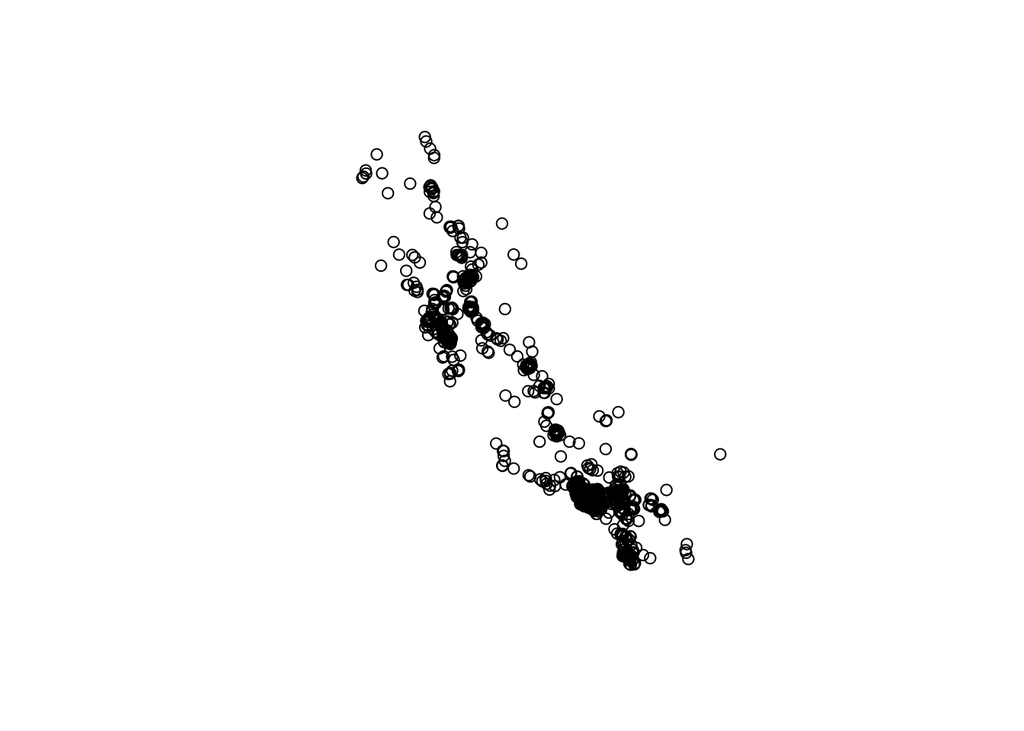

```r
# plot the sf object created above now that it's been geoprocessed
plot(mpv_2017_CA_long_lat_sf)
```

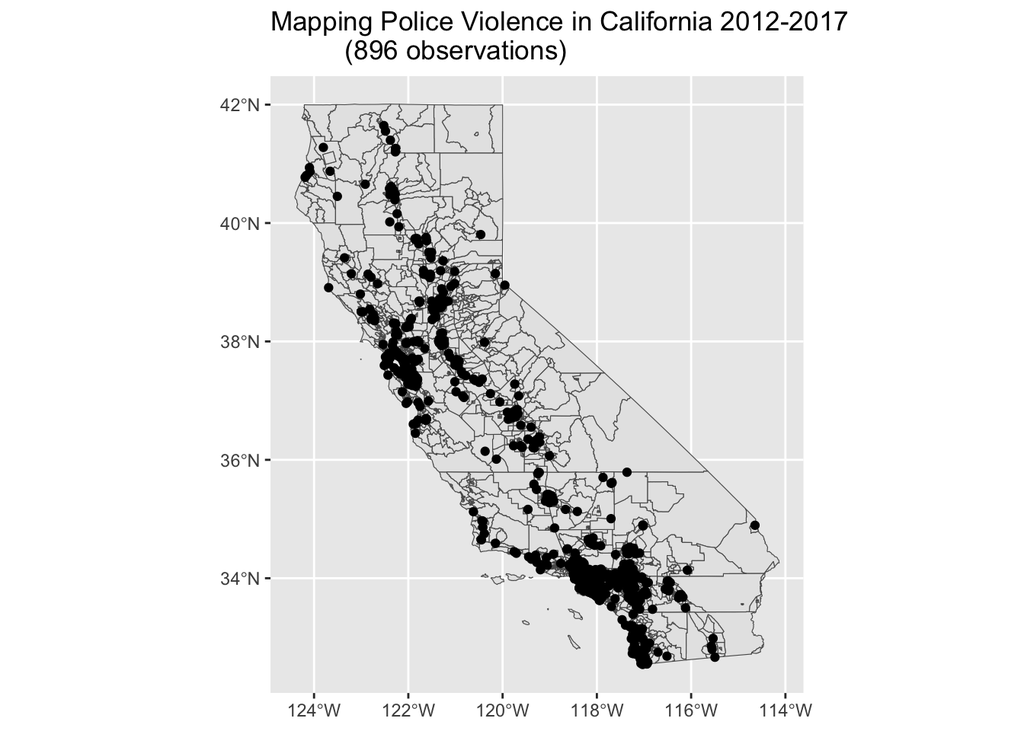

```r
# better visualization of the point data, overlaying CA shapefile
ggplot(ca) +
  geom_sf() +
  geom_sf(data = mpv_2017_CA_long_lat_sf) +
  ggtitle("Mapping Police Violence in California 2012-2017
          (896 observations)")
```

### Extracting the FIPS codes for Census Tracts where police violence occurred

```r
# variable for all CA census tracts -- retrieving from tidycensus api
ca_tracts <- tracts("CA", class = "sf") %>%
  select(GEOID, TRACTCE)
# creating boundaries around all CA census tracts
CA_bbox <- st_bbox(ca_tracts)
```

```r
# just st_join to find intersections of point data and/within CA census tracts
CA_points_tract <- st_join(mpv_2017_CA_long_lat_sf, ca_tracts) # spits out the tracts associated with the points
CA_points_tract # 953 observations since many Census Tract IDs are duplicates (multiple instances of police violence)
```

|  | geometry | GEOID | TRACTCE |
| --- | --- | --- | --- |
| 1 |  | 06029004903 | 004903 |
| 2 |  | 06081610202 | 610202 |
| 3 |  | 06037134802 | 134802 |
| 4 |  | 06037535901 | 535901 |
| 5 |  | 06107002903 | 002903 |
| 6 |  | 06065044510 | 044510 |
| 7 |  | 06037134201 | 134201 |
| 8 |  | 06045011600 | 011600 |
| 9 |  | 06073018516 | 018516 |
| 10 |  | 06029005600 | 005600 |

[output cut: 943 more lines]

### Create the dataframe to store all the fips codes for CA

```r
tract_IDs_CA <- c(CA_points_tract$GEOID)
```

```r
length(tract_IDs_CA) # 953 CA instances with census tracts
```

```
## [1] 953
```

```r
length(unique(tract_IDs_CA)) # 863 unique census tracts
```

```
## [1] 863
```

# Final list of Census Tract IDs

### Remove duplicates for final list

```r
tract_IDs_CA_final <- c(unique(tract_IDs_CA))
```

### Print final list

```r
length(tract_IDs_CA_final) # sanity check to make sure there's only 863
```

```
## [1] 863
```

```r
print(tract_IDs_CA_final) # print Census Tract FIPS codes that experienced police violence through 2017
```

```
##   [1] "06029004903" "06081610202" "06037134802" "06037535901" "06107002903"
##   [6] "06065044510" "06037134201" "06045011600" "06073018516" "06029005600"
##  [11] "06073007200" "06037554900" "06089011300" "06071003612" "06075023400"
##  [16] "06037123203" "06037535604" "06037403722" "06031001200" "06083002706"
##  [21] "06037127210" "06037127220" "06037127803" "06037127804" "06103000300"
##  [26] "06077003403" "06071009501" "06029002902" "06067007424" "06085504805"
##  [31] "06065042208" "06077004203" "06099002402" "06097154201" "06047000603"
##  [36] "06073020026" "06037651101" "06115040702" "06037320201" "06037430003"
##  [41] "06001407102" "06001422000" "06075010800" "06073019803" "06059099406"
##  [46] "06073013401" "06037199900" "06037203300" "06085504308" "06037407001"
##  [51] "06023001001" "06067003700" "06037207306" "06065043820" "06085504412"
##  [56] "06067006102" "06073014002" "06083002005" "06007001500" "06037139506"
##  [61] "06029005407" "06037530202" "06037540700" "06001451300" "06037262400"
##  [66] "06097152903" "06037224200" "06073005700" "06013365003" "06107001305"
##  [71] "06115041102" "06047002303" "06065046602" "06031001702" "06039000301"
```

[output cut: 158 more lines]